# datafsm Example

John J. Nay

August 20, 2015

```r
install.packages("datafsm")
library(datafsm) # Load and attach datafsm into your R session
```

[Estimating a model](https://raw.githubusercontent.com/JohnNay/datafsm/master/R/evolve_model.R) is as simple as ensuring the input data, e.g. `prepped`, is in the correct format and calling `evolve_model(prepped)`. Here, we loop through the six experimental treatments in the data and estimate a separate model for each, storing the results in a list we name `res`. The `parallel` argument allows this work to automatically be spread across all available processors on the computer. This parallelization, combined with the implementation of the [core computation](https://raw.githubusercontent.com/JohnNay/datafsm/master/src/fitnessCPP.cpp) in `C++`, speeds up estimation considerably.

```r
prepped <- data.frame(outcome = as.integer(ifelse(data[, "my.decision"]=="coop", 1, 2)),
                      period = as.integer(data[ , "period"]),
                      my.decision1 = as.integer(ifelse(data[, "my.decision1"]==1, 1, 0)),
                      other.decision1 = as.integer(ifelse(data[, "other.decision1"]==1, 1, 0)))
res <- lapply(as.list(group_indices), function(x){
  evolve_model(prepped[data$group==x,], parallel = TRUE)
})
```

The resulting object has methods for inspecting (`print`, `show`, `summary`, `estimation_details`, `best_performance`, `varImp`, `states`), visualizing (`plot`, `barplot`, `dotchart`), and predicting new data (`predict`). Below we use the `plot` and `barplot` methods to see the resulting model and the associated relative importance of the predictor variables. In this case, the predictor variables are the outcomes of the decisions in the previous period of the game and the outcome variable (the current state) is the action the model predicts the agent will take in the current period. The state on the far left is the starting state.

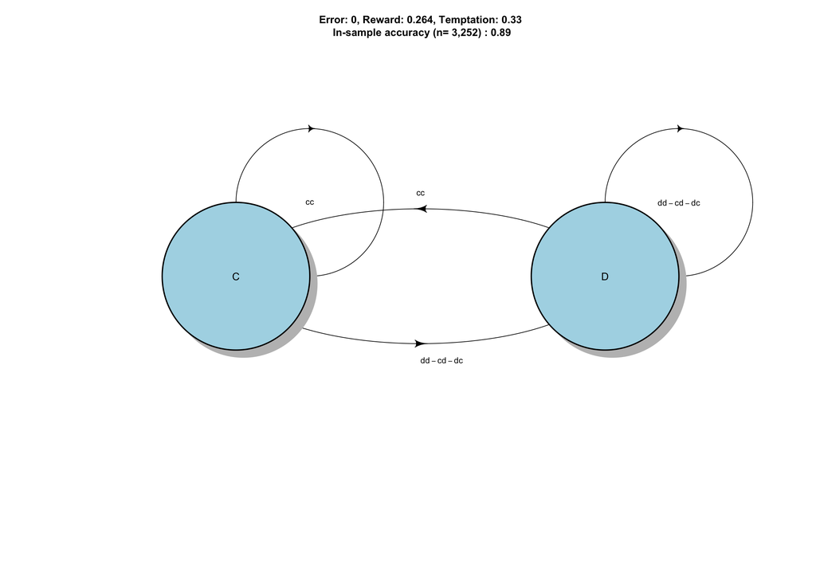

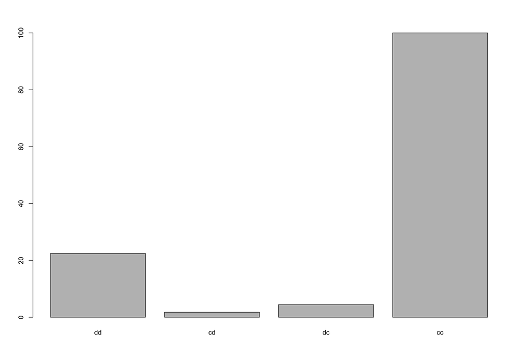

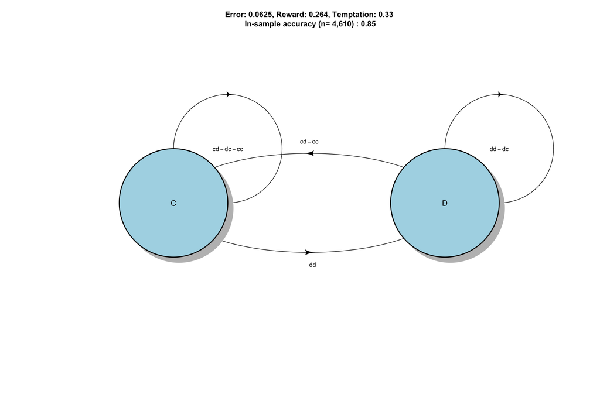

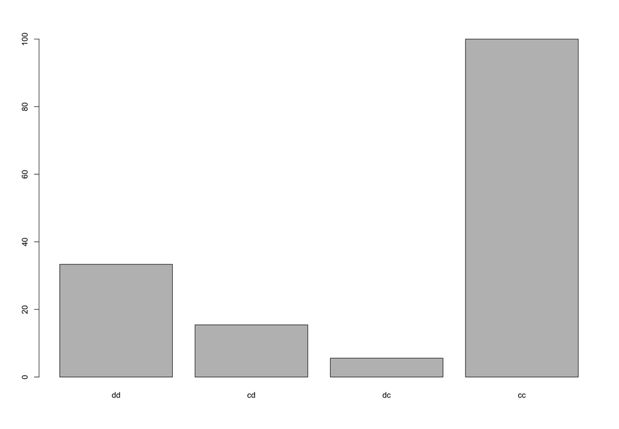

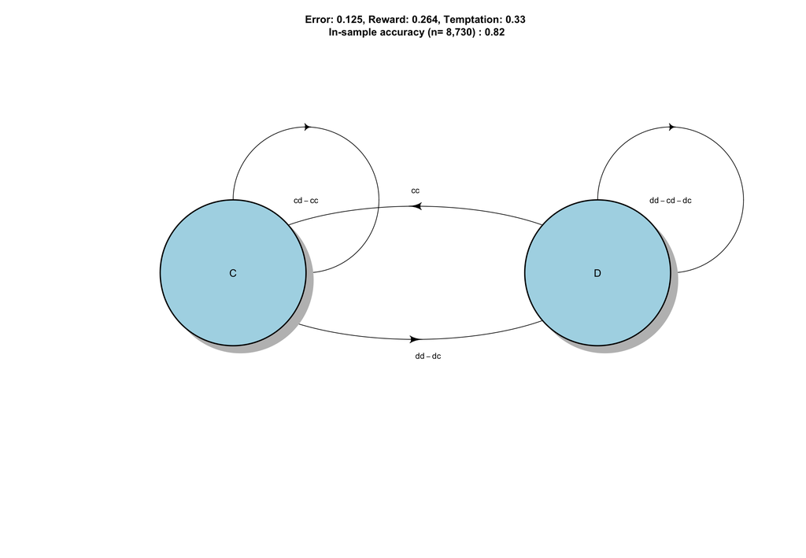

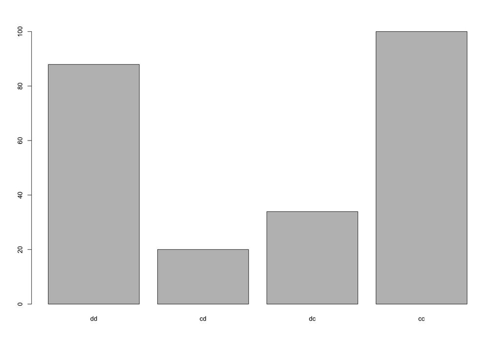

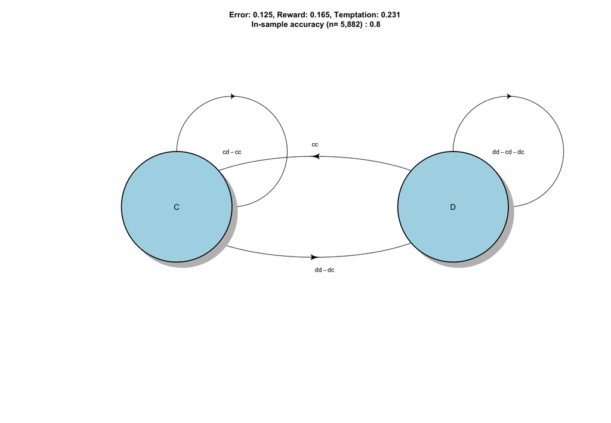

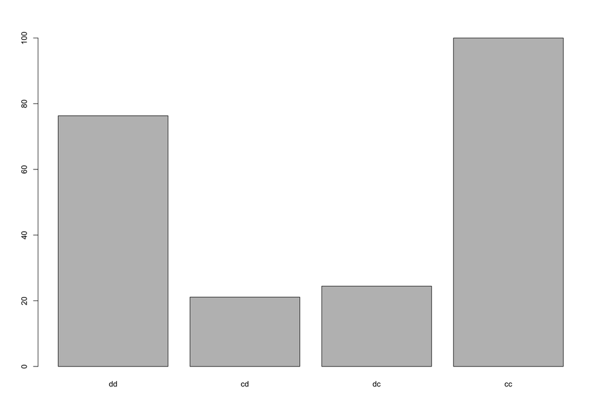

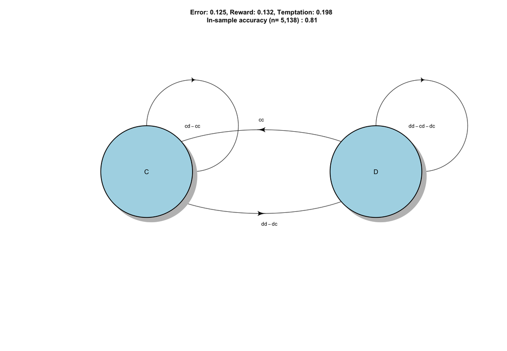

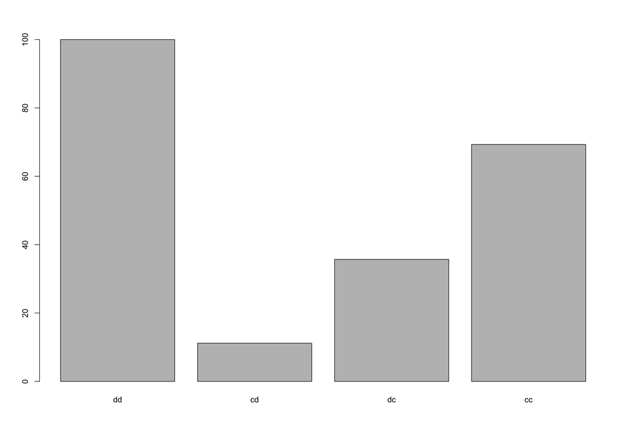

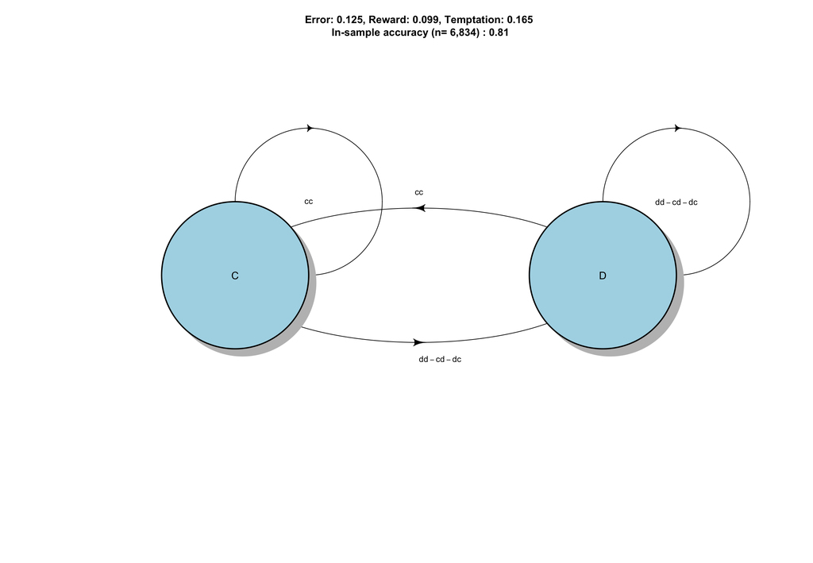

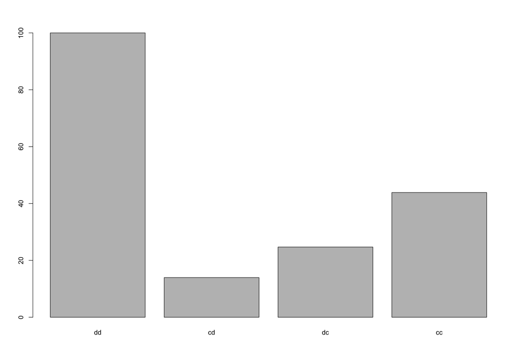

```r
names(res) <- group_indices
tl = c("dd", "cd", "dc", "cc")
for(name in names(res)){
  plot(res[[name]], action_label = ifelse(action_vec(res[[name]])==1, "C", "D"),
       transition_label = tl,
       maintitle = paste0("Error: ", patterns[name, "error"],
                          ", Reward: ", patterns[name, "r"],
                          ", Temptation: ", patterns[name, "t"],
                          "\n In-sample accuracy (n= ",
                          formatC(sum(data$group==name),big.mark=',',digits=0),") : ",
                          round(best_performance(res[[name]]),2)))
   barplot(res[[name]], names.arg=tl)
}
```

These variable importance plots of the six models capture ways in which the game design affects player behavior. The first two models are from the games where the error is zero or low: the `cc` outcome is by far the strongest predictor of play. Compare this to the next four models where error is higher: the `dd` becomes much more important. Now compare the third and fourth models from games with payoffs more amenable to cooperation to the fifth and sixth models from games with payoffs less amenable to cooperation: the `dd` outcome is more important in the latter. We can summarize this main pattern with a table.

```r
c_minus_d <- sapply(res, function(x) varImp(x)[4] - varImp(x)[1])
df <- cbind(patterns[group_indices, which(names(patterns) %in%
                                            c("error", "r", "t"))], c_minus_d)
names(df) <- c("Error", "Reward", "Temptation", "CC Imp. Rel. to DD")
row.names(df) <- NULL; pander(df)
```

| Error | Reward | Temptation | CC Imp. Rel. to DD |
| --- | --- | --- | --- |
| 0 | 0.264 | 0.33 | 77.55 |
| 0.0625 | 0.264 | 0.33 | 66.67 |
| 0.125 | 0.264 | 0.33 | 12.09 |
| 0.125 | 0.165 | 0.231 | 23.68 |
| 0.125 | 0.132 | 0.198 | -30.7 |
| 0.125 | 0.099 | 0.165 | -56.15 |

These were all two-state models, which is the default. When we call `evolve_model` we can either manually set the number of states, `states`, or we can set the argument `cv` to `TRUE`, which then estimates the out-of-sample performance through *k*-fold [cross-validation](https://raw.githubusercontent.com/JohnNay/datafsm/master/R/evolve_model_cv.R) on the training data for many values of the number of states to determine the number of states with best out-of-sample performance for the given dataset (and the given split into *k*-folds, which it should be relatively insensitive to).

```r
res2 <- lapply(as.list(group_indices), function(x){
  evolve_model(prepped[data$group==x,], parallel = TRUE,
               cv = TRUE, max_states = 6, k = 5)
})
```

```r
names(res2) <- group_indices
res2states <- sapply(res2, states)
df <- cbind(patterns[names(res2states), which(names(patterns) %in%
                                                c("error", "r", "t"))], res2states)
names(df) <- c("Error", "Reward", "Temptation", "States"); row.names(df) <- NULL
pander(df)
```

| Error | Reward | Temptation | States |
| --- | --- | --- | --- |
| 0 | 0.264 | 0.33 | 2 |
| 0.0625 | 0.264 | 0.33 | 4 |
| 0.125 | 0.264 | 0.33 | 4 |
| 0.125 | 0.165 | 0.231 | 4 |
| 0.125 | 0.132 | 0.198 | 6 |
| 0.125 | 0.099 | 0.165 | 4 |

References

Fudenberg, Drew, David G Rand, and Anna Dreber. 2012. “Slow to Anger and Fast to Forgive: Cooperation in an Uncertain World.” *American Economic Review* 102 (2): 720–49. doi:10.1257/aer.102.2.720.

Nay, John J., and Jonathan M. Gilligan. 2015. “Data-Driven Dynamic Decision Models.” In *Proceedings of the 2015 Winter Simulation Conference*, edited by L. Yilmaz, W.K.V. Chan, I. Moon, T.M.K. Roeder, C. M. Macal, and M. Rosetti. IEEE.